# Sharpe Ratio Notebook

Briefly, the Sharpe Ratio is the mean of the excess portfolio returns above the risk-free rate, divided by the standard deviation of the excess monthly returns above the risk-free rate. This is the formulation of the Sharpe Ratio as of 1994; if we wished to use the original formulation from 1966 the denominator would be the standard deviation of portfolio monthly returns. Learn more [here](http://web.stanford.edu/~wfsharpe/art/sr/sr.htm).

In other words, the Sharpe Ratio measures excess returns per unit of volatility, where we take the standard deviation to represent portfolio volatility. The Sharpe Ratio was brought to us by Bill Sharpe - arguably the most important economist for modern investment management as the creator of the Sharpe Ratio, CAPM and Financial Engines, a forerunner of today’s robo-advisor movement.

The Sharpe Ratio eqation is as follows:

$$Sharpe~Ratio={(\overline{R_{p}-R_{f}})}/\sigma_{excess}$$

The numerator is the mean excess return above the risk free rate and the numerator is the standard deviation of those excess returns. In other words, it’s a ratio of return to risk and so a higher Sharpe Ratio indicates a ‘better’ portfolio.

As for our project, we will proceed in 3 steps:

```
1. Build a portfolio and calculate the Sharpe Ratio using 3 methods (today's post)
2. Visualize the Sharpe Ratio using ggplot and highcharter (next week)
3. Wrap to an interactive Shiny App (in two weeks)
```

When working with the Sharpe Ratio, we have two critical choices: how to construct the portfolio using assets and weights, and which risk free to use. We’ve already chosen a portfolio so that leaves a risk free rate.

Risk Free Rate

[output not shown]

Let’s load our packages:

```r
library(tidyverse)
library(tidyquant)
library(timetk)
```

Before we do anything else, let’s assign the risk free rate to a variable called `rfr`.

```r
rfr <- .00008
```

On to the Sharpe analysis. Calculating the Sharpe Ratio in the `xts` world is almost depressingly convenient. We call `SharpeRatio(portfolio_returns_xts, MAR = MAR)`, passing our portfolio returns and MAR tot he built-in function from `PerformanceAnalytics`.

```r
sharpe_xts <-
  SharpeRatio(portfolio_returns_xts_rebalanced_monthly, Rf = rfr) %>%
  `colnames<-`("ratio")
```

From a substantive perspective, we could stop here and start visualizing with `highcharter`.

Instead, we will run the calculation by-hand, implementing the equation for the Sharpe Ratio via pipes and `dplyr`. It’s not a verbose piped workflow. In short, we call `summarise(ratio = mean(returns - rfr)/sd(returns - rfr))`.

```r
sharpe_byhand <-
  portfolio_returns_tq_rebalanced_monthly %>%
  summarise(ratio = mean(returns - rfr)/sd(returns - rfr))
sharpe_xts[1]
```

```
[1] 0.2578586
```

```r
sharpe_byhand
```

| ratio |
| --- |
| 0.2578586 |

Now on to `tidyquant`, which allows us to apply the `SharpeRatio` function from `PerformanceAnalytics` to a `tibble`.

```r
sharpe_tidy <-
  portfolio_returns_tq_rebalanced_monthly %>%
  tq_performance(Ra = returns,
                 performance_fun = SharpeRatio,
                 Rf = rfr) %>%
  select(2) %>%
  `colnames<-`("ratio")
```

Let’s compare our 3 Sharpe objects.

```r
sharpe_xts[1]
```

```
[1] 0.2578586
```

```r
sharpe_byhand$ratio
```

```
[1] 0.2578586
```

```r
sharpe_tidy$ratio
```

```
[1] 0.2578586
```

We have consistent results from `xts`, `tidyquant` and our by-hand piped calculation. It might feel like a lot of work to get the same result three times but, again, it forced us to look under the hood of the built-in functions and it might serve us well in the future should we have data or a project that fits better with one of the three methods.

When we originally calculated Sharpe by-hand in the tidy world, we used `summarise` to create one new cell for our end result. The code was `summarise(ratio = mean(returns - rfr)/sd(returns - rfr))`.

Now, we will make two additions to assist in our data visualization. We will add a column for returns that follow below rfr with `mutate(returns_below_rfr = ifelse(returns < rfr, returns, NA))` and add a column for returns above rfr with `mutate(returns_above_rfr = ifelse(returns > rfr, returns, NA))`. This is not necessary for calculating the Sortino, but we will see how it makes our ggplotting a bit easier and it illustrates a benefit of doing things by-hand with `dplyr`: if we want to extract or create certain data tranformations, we can add it to the piped code flow.

[output not shown]

We now have two objects in our global environment, `sharpe_xts` and `sharpe_byhand`.

Let’s work with `sharpe_byhand` and start with a scatterplot of returns using `ggplot`.

The goal is to quickly grasp how many of our returns are above the rfr and how many are below the rfr. When we calculated the sharpe above, we created new columns for `returns_above_rfr` and `returns_below_rfr` columns. It makes this visualization a straightforward construct.

We will create green points for returns above rfr with `geom_point(aes(y = returns_above_rfr), colour = "green")` and red points for returns below rfr with `geom_point(aes(y = returns_below_rfr), colour = "red")`.

I’m always curious how portfolios have performed since the election so we’ll add a blue vertical line at November of 2016. We will also include a horizontal purple dotted line at the rfr.

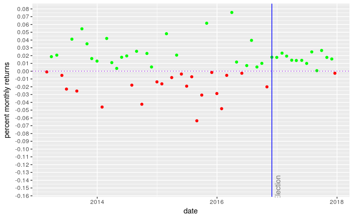

```r
sharpe_byhand %>%
  ggplot(aes(x = date)) +
  geom_point(aes(y = returns_below_rfr), colour = "red") +
  geom_point(aes(y = returns_above_rfr), colour = "green") +
  geom_vline(xintercept = as.numeric(as.Date("2016-11-30")), color = "blue") +
  geom_hline(yintercept = rfr, color = "purple", linetype = "dotted") +
  annotate(geom="text", x=as.Date("2016-11-30"),
           y = -.15, label = "Election", fontface = "plain",
           angle = 90, alpha = .5, vjust =  1.5) +
  ylab("percent monthly returns") +
  scale_y_continuous(breaks = pretty_breaks(n=20))
```

Next we will build a histogram of the distribution of returns with `geom_histogram(alpha = 0.25, binwidth = .01, fill = "cornflowerblue")`. We will again add a line for the MAR.

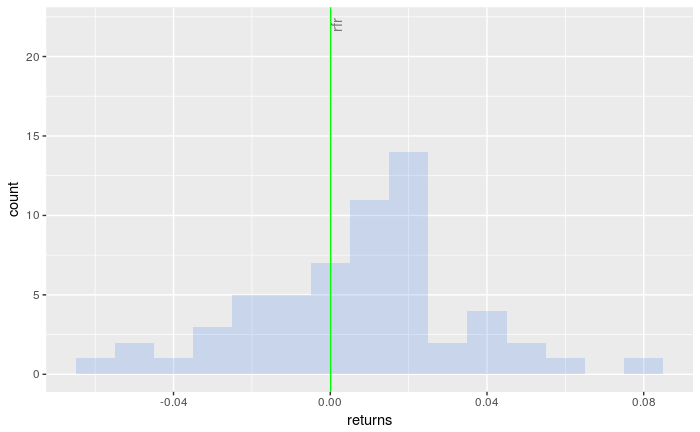

```r
sharpe_byhand %>%
  ggplot(aes(x = returns)) +
  geom_histogram(alpha = 0.25, binwidth = .01, fill = "cornflowerblue") +
  geom_vline(xintercept = rfr, color = "green") +
  annotate(geom = "text", x = rfr,
    y = 22, label = "rfr", fontface = "plain", angle = 90, alpha = .5, vjust =  1)
```

I notice a slight negative skew and a mode that is above the risk free rate. That’s good because if our mode were below the risk free rate we wouldn’t last long in this business.

We have not, however, visualized the actual Sharpe Ratio yet. We will do so now.

The ratio itself is one number: 0.258. Similar to the standard deviation or volatility of returns, that doesn’t allow much by way of dynamic visualization and it might obscure important periods in our data.

First, we need to calculate the rolling 6-month Sharpe Ratio with `rollapply(portfolio_returns_xts_rebalanced_monthly, 6, function(x) SharpeRatio(x, Rf = rfr, FUN = "StdDev"))`. Note that we need to pass in the argument `FUN = "StdDev"`. Try running the code without that argument check out the error.

```r
sharpe_roll_6_xts
```

```
                returns
2013-02-28           NA
2013-03-28           NA
2013-04-30           NA
2013-05-31           NA
2013-06-28           NA
2013-07-31  0.372313719
2013-08-30  0.163831135
2013-09-30  0.307630670
2013-10-31  0.364869380
2013-11-29  0.483719670
2013-12-31  0.793885271
2014-01-31  0.208379155
2014-02-28  0.536316405
2014-03-31  0.380894603
2014-04-30  0.227028136
2014-05-30  0.235820982
2014-06-30  0.270209546
2014-07-31  0.638422194
2014-08-29  0.633534753
2014-09-30  0.037404477
2014-10-31  0.150151697
2014-11-28  0.077670279
2014-12-31 -0.131406829
2015-01-30 -0.121542155
2015-02-27  0.018518154
2015-03-31  0.251338029
2015-04-30  0.239555957
2015-05-29  0.176337854
2015-06-30  0.135131016
2015-07-31  0.202327599
2015-08-31 -0.488397796
2015-09-30 -0.608977105
2015-10-30 -0.254298776
2015-11-30 -0.245631776
2015-12-31 -0.279713506
2016-01-29 -0.418432424
2016-02-29 -0.229964997
2016-03-31  0.178541709
2016-04-29  0.011848105
2016-05-31  0.007783052
2016-06-30  0.157997673
2016-07-29  0.673131449
2016-08-31  0.769066827
2016-09-30  0.818243996
2016-10-31  0.334769930
2016-11-30  0.514514051
2016-12-30  0.599679652
2017-01-31  0.575043727
2017-02-28  0.706530057
2017-03-31  0.747865472
2017-04-28  5.028454908
2017-05-31  4.441681446
2017-06-30  3.310331038
2017-07-31  3.034928793
2017-08-31  1.646685290
2017-09-29  1.545632345
2017-10-31  1.608171168
2017-11-30  1.644637775
2017-12-19  1.125220134
```

Let’s chart with `highcharter` and investigate any unusual occurrences.

```r
highchart(type = "stock") %>%
  hc_title(text = "Rolling Sharpe") %>%
  hc_add_series(sharpe_roll_6_xts, name = "sharpe", color = "blue") %>%
  hc_navigator(enabled = FALSE) %>%
  hc_scrollbar(enabled = FALSE)
```

[interactive chart not shown]

A huge spike in 2017 as our genius is validated! Recall that the rolling contribution to volatility of EEM spiked in 2017 as well. There seems to be something afoot during those first six-months.

Let’s see how the rolling 12-month compares and whether it smooths out these spikes.

```r
sharpe_roll_12_xts <- rollapply(portfolio_returns_xts_rebalanced_monthly, 12,
                           function(x) SharpeRatio(x, Rf = rfr, FUN = "StdDev"))
highchart(type = "stock") %>%
  hc_title(text = "Rolling sharpe") %>%
  hc_add_series(sharpe_roll_12_xts, name = "sharpe 24", color = "green") %>%
  hc_navigator(enabled = FALSE) %>%
  hc_scrollbar(enabled = FALSE)
```

[interactive chart not shown]

There’s still a spike in 2017 but of a smaller magnitude.